# Introduction to R for Biologists

BIOL 4994/BIOL 4991 undegrads BIOL 6994/BIOL 6997 grads

Alan J. Figueroa Ruiz

2025-Sep-04, 11:17 PM

# Asignacion 1

# Homework 1

### Instructions / Instrucciones generales

- This assignment consists of 10 questions, each worth **10 points**.  
  (Esta tarea consta de 10 preguntas, cada una vale **10 puntos**.)
- Write your answers in R code chunks whenever applicable.  
  (Escribe tus respuestas en chunks de R cuando sea aplicable.)
- Make sure your code runs without errors. Include comments if necessary.  
  (Asegúrate de que tu código se ejecute sin errores. Incluye comentarios si es necesario.)
- For questions about chunk options, experiment with the options and write down your observations.  
  (Para preguntas sobre opciones de chunks, experimenta con ellas y escribe tus observaciones.)
- Submit the assignment on your personal webpages using the **HTML file** exported/knit from the `.Rmd`.  
  Do not copy output screenshots unless requested.  
  (Entrega la tarea en tus páginas personales usando el **archivo HTML** generado/kniteado desde el `.Rmd`.  
  No copies capturas de pantalla del resultado a menos que se indique.)

#### **Assigning values**

**Q1.** Create an object called height with the value 175. Print it. (Crea un objeto llamado height con el valor 175. Muéstralo en pantalla.)

```r
height <- 175
height
```

```
## [1] 175
```

#### **Simple math**

**Q2.** Calculate the result of 25 * 4 - 10. (Calcula el resultado de 25 * 4 - 10.)

```r
25 * 4 - 10
```

```
## [1] 90
```

#### **Using functions**

**Q3.** Use the function sqrt() to calculate the square root of 81. (Usa la función sqrt() para calcular la raíz cuadrada de 81.)

```r
sqrt(81)
```

```
## [1] 9
```

#### **Character objects**

**Q4.** Assign the phrase “R is fun!” to an object called message. Print it. (Asigna la frase “R is fun!” a un objeto llamado message. Muéstralo.)

```r
message <- "R is fun!"
```

[output not shown]

#### **Object manipulation**

**Q5.** Create two objects a <- 10 and b <- 5. Calculate their sum and store it in c. (Crea dos objetos a <- 10 y b <- 5. Calcula su suma y guárdala en c.)

```r
a <- 10
b <- 5
c <- a + b
c
```

```
## [1] 15
```

#### **Logical comparison**

**Q6.** Test whether 15 is greater than 20. (Verifica si 15 es mayor que 20.)

```r
15 > 20
```

```
## [1] FALSE
```

#### **Checking classes**

**Q7.** Check the class of the object `"Hello World"`. (Verifica la clase del objeto `"Hello World"`.)

```r
obj7 <- "Hello World"
class(obj7)
```

```
## [1] "character"
```

#### **Code chunk options**

**Q8.** Run the following code chunk:  
- Observe the warnings that appear. (Observa las advertencias que aparecen.)  
- Modify the chunk options **to suppress warnings** without changing the code itself. (Modifica las opciones del chunk para **apagar la advertencia** sin cambiar el código.)

```r
log(-1)
```

```
## Warning in log(-1): NaNs produced
```

```
## [1] NaN
```

```r
log(-1)
```

```
## [1] NaN
```

#### **Code chunk options**

**Q9.** Run the following code chunk: - Observe the messages that appear. (Observa los mensajes que aparecen.)

- Modify the chunk options to suppress messages without changing the code itself. (Modifica las opciones del chunk para apagar mensajes sin cambiar el código.)

```r
# Load a package (may produce messages)
library(dplyr)
library(dplyr)
```

#### **Help files**

**Q10.** Use R’s help system to find out what the function `mean()` does. (Usa el sistema de ayuda de R para averiguar qué hace la función `mean()`.)

```r
?mean()
```

```
## starting httpd help server ... done
```

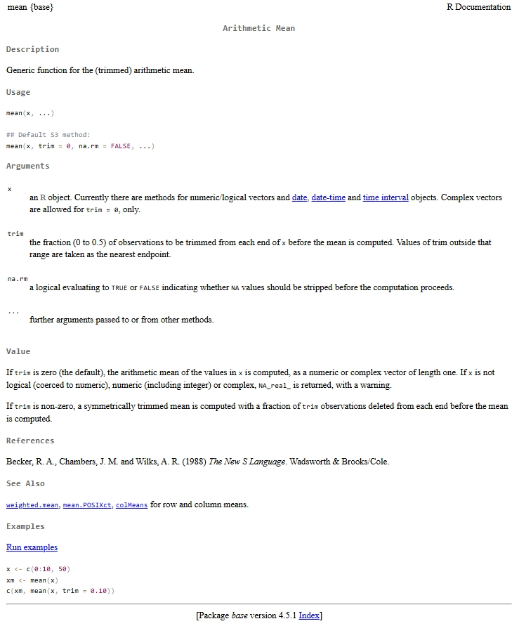